# Experiment Report

This report presents the analysis for **train_and_test_on_average_score**: Train and evaluate Task 1 model on averaged scores.

Tue Dec 31 12:01:10 2024

## Description of the data

### Responses excluded due to non-numeric feature values or scores

**Training set**

Total number of excluded responses: 0 (0.0% of the original 1195)

**Evaluation set**

Total number of excluded responses: 0 (0.0% of the original 288)

The rest of this report is based only on the responses that were not excluded above.

Composition of the training and evaluation sets

| partition | responses |
| --- | --- |
| Training | 1195 |
| Evaluation | 288 |
| Overlapping | 0 |
| Total | 1483 |

## Overall descriptive feature statistics

These values are reported before transformations.

|  | mean | std. dev. | min | max | skewness | kurtosis | Correlation | p | N |
| --- | --- | --- | --- | --- | --- | --- | --- | --- | --- |
| %MISSPELLED | 0.032 | 0.023 | 0.000 | 0.267 | 2.555 | 17.315 | -0.191 | 0.000 | 1195 |
| AVG_WLEN | 4.331 | 0.252 | 3.577 | 5.159 | 0.275 | 3.210 | 0.261 | 0.000 | 1195 |
| LOGTYPES | 2.187 | 0.148 | 1.255 | 2.522 | -1.506 | 8.125 | 0.847 | 0.000 | 1195 |
| LOGWORDS | 2.580 | 0.182 | 1.342 | 2.943 | -1.850 | 10.047 | 0.836 | 0.000 | 1195 |

### Prevalence of recoded cases

This sections shows the number and percentage of cases truncated to mean +/- 4 SD for each feature.

[figure not shown]

### Feature value distribution

The following table shows additional statistics for the data. Quantiles are computed using type=3 method used in SAS. The mild outliers are defined as data points between [1.5, 3) * IQR away from the nearest quartile. Extreme outliers are the data points >= 3 * IQR away from the nearest quartile.

|  | 1% | 5% | 25% | 50% | 75% | 95% | 99% | IQR | Mild outliers | Extreme outliers |
| --- | --- | --- | --- | --- | --- | --- | --- | --- | --- | --- |
| %MISSPELLED | 0.000 | 0.007 | 0.017 | 0.028 | 0.040 | 0.070 | 0.112 | 0.023 | 35 | 13 |
| AVG_WLEN | 3.788 | 3.933 | 4.154 | 4.315 | 4.498 | 4.761 | 4.993 | 0.344 | 13 | 0 |
| LOGTYPES | 1.672 | 1.934 | 2.117 | 2.207 | 2.283 | 2.377 | 2.438 | 0.166 | 33 | 9 |
| LOGWORDS | 1.898 | 2.270 | 2.493 | 2.611 | 2.697 | 2.801 | 2.869 | 0.204 | 27 | 10 |

## Feature distributions and inter-feature correlations

### Training set distributions

The following plot shows the distributions of the feature values in the training set, after transformation (if applicable), truncation and standardization (if applicable). The line shows the kernel density estimate. The human score (`sc1`) is also included.

Response length (`length`) is included if you specified `length_column` in the config file, unless the column had missing values or a standard deviation <= 0.

[figure not shown]

### Inter-feature correlations

The following table shows the Pearson correlations between all the training features after transformation (if applicable), truncation and standardization (if applicable). The human score (`sc1`) is also included.

Response length (`length`) is included if you specified `length_column` in the config file, unless the column had missing values or a standard deviation <= 0.

The following values are highlighted:

- inter-feature correlations above 0.7, and
- `sc1`-feature correlations lower than 0.1 or higher than 0.7

|  | sc1 | %MISSPELLE D | AVG_WLEN | LOGTYPES | LOGWORDS |
| --- | --- | --- | --- | --- | --- |
| sc1 | 1.000 | 0.174 | 0.261 | 0.846 | 0.837 |
| %MISSPELLED | 0.174 | 1.000 | 0.018 | 0.130 | 0.200 |
| AVG_WLEN | 0.261 | 0.018 | 1.000 | 0.205 | 0.098 |
| LOGTYPES | 0.846 | 0.130 | 0.205 | 1.000 | 0.939 |
| LOGWORDS | 0.837 | 0.200 | 0.098 | 0.939 | 1.000 |

### Marginal and partial correlations

The plot below shows correlations between truncated and standardized (if applicable) values of each feature against human score. The first bar (`Marginal`) in each case shows Pearson's correlation. The second bar (`Partial - all`) shows partial correlations after controlling for all other variables. If you specified `length_column` in the config file, a third bar (`Partial - length`) will show partial correlations of each feature against the human score after controlling for length. The dotted lines correspond to *r* = 0.1 and *r* = 0.7.

[figure not shown]

Consistency

The configuration file did not specify `second_human_score_column` which is necessary to compute consistency metrics.

## Model

Model used: **LinearRegression**

Number of features in model: **4**

Model summary

```
                            OLS Regression Results
==============================================================================
Dep. Variable:                    sc1   R-squared:                       0.749
Model:                            OLS   Adj. R-squared:                  0.748
Method:                 Least Squares   F-statistic:                     887.3
Date:                Tue, 31 Dec 2024   Prob (F-statistic):               0.00
Time:                        12:01:06   Log-Likelihood:                -551.82
No. Observations:                1195   AIC:                             1114.
Df Residuals:                    1190   BIC:                             1139.
Df Model:                           4
Covariance Type:            nonrobust
===============================================================================
                  coef    std err          t      P>|t|      [0.025      0.975]
-------------------------------------------------------------------------------
const           4.2707      0.011    383.675      0.000       4.249       4.293
%MISSPELLED     0.0235      0.012      2.034      0.042       0.001       0.046
AVG_WLEN        0.1036      0.012      8.726      0.000       0.080       0.127
LOGTYPES        0.3051      0.035      8.758      0.000       0.237       0.373
LOGWORDS        0.3403      0.035      9.818      0.000       0.272       0.408
==============================================================================
Omnibus:                       22.602   Durbin-Watson:                   2.029
Prob(Omnibus):                  0.000   Jarque-Bera (JB):               24.465
Skew:                           0.297   Prob(JB):                     4.87e-06
Kurtosis:                       3.373   Cond. No.                         6.24
==============================================================================

Notes:
[1] Standard Errors assume that the covariance matrix of the errors is correctly specified.
```

Model fit

| N responses | N features | R2 | R2_adjusted |
| --- | --- | --- | --- |
| 1195 | 4 | 0.749 | 0.748 |

### Standardized and relative regression coefficients (betas)

The relative coefficients are intended to show relative contribution of different feature and their primary purpose is to indentify whether one of the features has an unproportionate effect over the final score. They are computed as standardized/(sum of absolute values of standardized coefficients).

Negative standardized coefficients are highlighted.

**Note**: if the model contains negative coefficients, relative values will not sum up to one and their interpretation is generally questionable.

| feature | standardized | relative |
| --- | --- | --- |
| %MISSPELLED | 0.031 | 0.030 |
| AVG_WLEN | 0.135 | 0.134 |
| LOGTYPES | 0.398 | 0.395 |
| LOGWORDS | 0.444 | 0.441 |

Here are the same values, shown graphically.

[figure not shown]

Model diagnostics

These are standard plots for model diagnostics for the main model. All information is computed based on the training set.

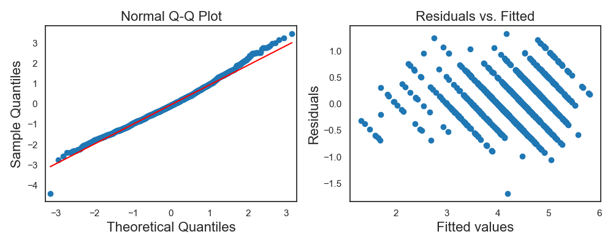

## Evaluation results

### Overall association statistics

The tables in this section show the standard association metrics between *observed* human scores and different types of machine scores. These results are computed on the evaluation set. `raw_trim` scores are truncated to [0.5002, 6.4998000000000005]. `raw_trim_round` scores are computed by first truncating and then rounding the predicted score. Scaled scores are computed by re-scaling the predicted scores using mean and standard deviation of human scores as observed on the training data and mean and standard deviation of machine scores as predicted for the training set.

#### Descriptive holistic score statistics

The table shows distributional properties of human and system scores. SMD values lower then -0.15 or higher than 0.15 are highlighted.

*Please note that for raw scores, SMD values are likely to be affected by possible differences in scale.*

|  | N | h_mean | sys_mean | h_sd | sys_sd | h_min | sys_min | h_max | sys_max | SMD |
| --- | --- | --- | --- | --- | --- | --- | --- | --- | --- | --- |
| raw | 288 | 4.274 | 4.284 | 0.699 | 0.558 | 2.500 | 2.782 | 6.000 | 5.684 | 0.015 |
| raw_trim | 288 | 4.274 | 4.284 | 0.699 | 0.558 | 2.500 | 2.782 | 6.000 | 5.684 | 0.015 |
| raw_trim_round | 288 | 4.274 | 4.267 | 0.699 | 0.620 | 2.500 | 3.000 | 6.000 | 6.000 | -0.010 |
| scale | 288 | 4.274 | 4.287 | 0.699 | 0.645 | 2.500 | 2.550 | 6.000 | 5.904 | 0.018 |
| scale_trim | 288 | 4.274 | 4.287 | 0.699 | 0.645 | 2.500 | 2.550 | 6.000 | 5.904 | 0.018 |
| scale_trim_round | 288 | 4.274 | 4.309 | 0.699 | 0.677 | 2.500 | 3.000 | 6.000 | 6.000 | 0.050 |

#### Association statistics

The table shows the standard association metrics between human scores and machine scores. Note that for computation of `kappa` both human and machine scores are rounded.

|  | N | corr | wtkappa | R2 | kappa | exact_agr | adj_agr | RMSE |
| --- | --- | --- | --- | --- | --- | --- | --- | --- |
| raw | 288 | 0.796 | 0.776 | 0.634 | 0.425 | 0.000 | 96.528 | 0.423 |
| raw_trim | 288 | 0.796 | 0.776 | 0.634 | 0.425 | 0.000 | 96.528 | 0.423 |
| raw_trim_round | 288 | 0.714 | 0.709 | 0.480 | 0.425 | 53.819 | 98.958 | 0.503 |
| scale | 288 | 0.796 | 0.793 | 0.618 | 0.397 | 0.000 | 96.528 | 0.432 |
| scale_trim | 288 | 0.796 | 0.793 | 0.618 | 0.397 | 0.000 | 96.528 | 0.432 |
| scale_trim_round | 288 | 0.693 | 0.691 | 0.401 | 0.397 | 50.694 | 98.611 | 0.540 |

### Confusion matrix

Confusion matrix using raw, trimmed, and rounded scores and human scores (rows=human, columns=system). Note: Human scores have beeen rounded to the nearest integer.

|  | 2 | 3 | 4 | 5 | 6 |
| --- | --- | --- | --- | --- | --- |
| 2 | 0 | 1 | 0 | 0 | 0 |
| 3 | 0 | 16 | 6 | 0 | 0 |
| 4 | 0 | 8 | 146 | 43 | 0 |
| 5 | 0 | 0 | 10 | 32 | 0 |
| 6 | 0 | 0 | 1 | 23 | 2 |

### Distribution of human and machine scores

The histogram and the table below show the distibution of human scores and raw, trimmed, and rounded machine scores (as % of all responses). Differences in the table between human and machine distributions larger than 5 percentage points are highlighted. Note: Human scores have beeen rounded to the nearest integer.

[figure not shown]

| score | human | sys_raw | difference |
| --- | --- | --- | --- |
| 2.0 | 0.347222 | 0.000000 | -0.347 |
| 3.0 | 7.638889 | 8.680556 | 1.042 |
| 4.0 | 68.402778 | 56.597222 | -11.806 |
| 5.0 | 14.583333 | 34.027778 | 19.444 |
| 6.0 | 9.027778 | 0.694444 | -8.333 |

True score evaluations

The configuration file did not specify `second_human_score_column` or `rater_error_variance`. At least one of these must be specified to compute evaluations against true scores.

## Principal component analysis

PCA using scaled data and singular value decomposition. This is computed using processed features after the truncation of outliers and other transformations specified in feature config file.

|  | PC1 | PC2 | PC3 | PC4 |
| --- | --- | --- | --- | --- |
| %MISSPELLED | -0.218 | -0.644 | 0.731 | -0.053 |
| AVG_WLEN | -0.201 | 0.759 | 0.614 | 0.081 |
| LOGTYPES | -0.677 | 0.059 | -0.201 | -0.706 |
| LOGWORDS | -0.674 | -0.077 | -0.218 | 0.702 |

|  | PC1 | PC2 | PC3 | PC4 |
| --- | --- | --- | --- | --- |
| Cumulative percentage of variance | 0.509 | 0.757 | 0.987 | 1.000 |
| Eigenvalues | 2.037 | 0.991 | 0.920 | 0.052 |
| Percentage of variance | 0.509 | 0.248 | 0.230 | 0.013 |

[figure not shown]

## Links to intermediate files

The following intermediate files were generated as part of this experiment.To examine a file, click on the link. Note that the descriptions provided here are only brief summaries. For more detailed descriptions, please refer to the [relevant RSMTool documentation](https://rsmtool.readthedocs.io/en/main/usage_rsmtool.html#intermediate-files).

| Filename | Description |
| --- | --- |
| betas | Standardized & relative regression coefficients |
| coefficients | Feature coefficients (including intercept) |
| coefficients_scaled | Scaled feature coefficients (including intercept) |
| confMatrix | Confusion matrix between human scores and machine scores |
| cors_orig | Correlations between raw features & between features and human score |
| cors_processed | Correlations between pre-processed features & between features and human score |
| data_composition | Data composition statistics |
| eval | Full set of evaluation metrics |
| eval_short | Subset of more commonly used evaluation metrics |
| feature | Feature values, signs, and transforms used in the final model |
| feature_descriptives | Main Descriptive statistics for raw feature values |
| feature_descriptivesExtra | Additional descriptive statistics for raw feature values |
| feature_outliers | Number and percentage of outliers trunctated during feature pre-processing |
| margcor_score_all_data | Marginal correlations between each pre-processed feature and human score |
| model_fit | R^2 and adjusted R^2 computed on the training set |
| pca | Results of principal components analysis on the pre-processed feature values |
| pcavar | Eigenvalues and variance explained by each principal component |
| pcor_score_all_data | Partial correlations between each pre-processed feature & human score, controlling for other features |
| postprocessing_params | Parameters used for trimming and scaling predicted scores |
| pred_processed | Predicted scores for the evaluation set |
| pred_train | Predicted scores for the training set |
| score_dist | Distributions of human and machine scores |
| test_excluded_composition | Composition of evaluation set responses excluded from analysis |
| test_features | Raw feature values for the evaluation set |
| test_metadata | Metadata columns for the evaluation set |
| test_other_columns | Unused columns for the evaluation set |
| test_preprocessed_features | Pre-processed feature values for the evaluation set |
| train_excluded_composition | Composition of training set responses excluded from analysis |
| train_features | Raw feature values for the training set |
| train_metadata | Metadata columns for the training set |
| train_other_columns | Unused columns for the training set |
| train_preprocessed_features | Pre-processed feature values for the training set |

## System information

This report was generated using rsmtool v12.0.0 on a 64bit computer running Mac OS X.

### Python packages

[output not shown]

[output cut: 114 more lines]

[output not shown]